# Case-Control Narrative Analysis

Max Flurie

2021-05-06

# 1 1. Libraries

**Overview**

This Markdown provides NLP procedures for contrasting language samples between a single case and a group of age-matched controls. In this study, participants were describing picture scenes. This study aimed to compare the two based on sensory (e.g., visual, auditory, tactile) and emotionality (e.g., valence, arousal) dimensions.

# 2 2. Import Data: Narratives, Lancaster Norms, and Warriner Norms

First, we need to import our language samples, norms for sensory language, and norms for emotional language

```r
####Load in Case Narratives
casenarratives <- read_excel("PictureNarratives.xlsx")
casenarratives<-as.data.frame(casenarratives)
head(casenarratives, 1)
```

|  | Number | Topic | Text |
| --- | --- | --- | --- |
| 1 | 1 | Baker | Ok so I imagine the baker is probably inspecting the bread for any kind of problems or defects\r\nshe might be you know kind of thinking about any customers coming in \r\nyou know maybe she’s worried … |

```r
####Load in Control Narratives
controlnarratives <- read_excel("ControlPictureNarratives2.xlsx")
controlnarratives<-as.data.frame(controlnarratives)
head(controlnarratives, 2)
```

|  | Number | Topic | Subject | Text |
| --- | --- | --- | --- | --- |
| 1 | 1 | Baker | CA01 | okay um feeling accomplished for having baked all the bread feeling tired because of having baked all the bread feeling tired um because of the repetitive actions for making all the bread um feeling h… |
| 2 | 2 | Trash | CA01 | Feeling disgusted um because of the various garbage there Um feeling inconvenienced because of having to cover up um because of the smells there Um maybe feeling angry It looks like she’s dressed um a… |

```r
####Load in Lancaster Norms (our sensory norms)
lancaster <- read_csv("LancasterNorms.csv")
lancaster<-as.data.frame(lancaster)
head(lancaster, 5)
```

|  | Word | Auditory.mean | Gustatory.mean | Haptic.mean | Interoceptive.mean | Olfactory.mean | Visual.mean | Foot_leg.mean | Hand_arm.mean | Head.mean | Mouth.mean | Torso.mean | Auditory.SD | Gustatory.SD | Haptic.SD | Interoceptive.SD | Olfactory.SD | Visual.SD | Foot_leg.SD | Hand_arm.SD | Head.SD | Mouth.SD | Torso.SD | Max_strength.perceptual | Minkowski3.perceptual | Exclusivity.perceptual | Dominant.perceptual | Max_strength.action | Minkowski3.action | … |
| --- | --- | --- | --- | --- | --- | --- | --- | --- | --- | --- | --- | --- | --- | --- | --- | --- | --- | --- | --- | --- | --- | --- | --- | --- | --- | --- | --- | --- | --- | --- |
| 1 | A | 2.214286 | 0.00000000 | 0.4285714 | 0.0000000 | 0.0000000 | 2.428571 | 0.0000000 | 0.3571429 | 1.071429 | 0.35714286 | 0.00000000 | 2.259291 | 0.0000000 | 0.9376145 | 0.0000000 | 0.0000000 | 2.408775 | 0.0000000 | 1.336306 | 2.129077 | 1.3363062 | 0.0000000 | 2.428571 | 2.934085 | 0.4788732 | Visual | 1.071429 | 1.097256 | … |
| 2 | A CAPPELLA | 4.333333 | 0.00000000 | 0.2222222 | 0.7222222 | 0.0000000 | 1.666667 | 0.3809524 | 0.4285714 | 2.714286 | 3.71428571 | 1.00000000 | 1.608799 | 0.0000000 | 0.5483189 | 1.3636265 | 0.0000000 | 1.909727 | 0.9734573 | 1.075706 | 1.901127 | 1.8477786 | 1.4491377 | 4.333333 | 4.420628 | 0.6240000 | Auditory | 3.714286 | 4.167341 | … |
| 3 | AARDVARK | 1.625000 | 0.56250000 | 1.6250000 | 0.0625000 | 1.2500000 | 4.125000 | 0.1764706 | 0.7058824 | 2.235294 | 0.05882353 | 0.05882353 | 1.784190 | 1.2632630 | 1.9278658 | 0.2500000 | 1.8797163 | 1.258306 | 0.5285941 | 1.311712 | 1.921243 | 0.2425356 | 0.2425356 | 4.125000 | 4.325018 | 0.4391892 | Visual | 2.235294 | 2.258902 | … |
| 4 | ABACK | 1.294118 | 0.05882353 | 0.2941176 | 1.3529412 | 0.0000000 | 2.823529 | 0.0000000 | 0.0000000 | 3.272727 | 0.36363636 | 0.18181818 | 1.896204 | 0.2425356 | 0.9851844 | 1.8007351 | 0.0000000 | 2.007339 | 0.0000000 | 0.000000 | 1.902152 | 0.9244163 | 0.6030227 | 2.823529 | 3.006634 | 0.4848485 | Visual | 3.272727 | 3.274410 | … |
| 5 | ABACUS | 1.555556 | 0.16666667 | 3.7222222 | 0.2777778 | 0.1111111 | 3.944444 | 0.0000000 | 2.4736842 | 2.631579 | 0.10526316 | 0.00000000 | 1.616904 | 0.5144958 | 1.4061025 | 0.6691132 | 0.4714045 | 1.304843 | 0.0000000 | 2.269812 | 2.191157 | 0.3153018 | 0.0000000 | 3.944444 | 4.887248 | 0.3920455 | Visual | 2.631579 | 3.219225 | … |

```r
####Load in Warriner Norms (our emotionality norms)
warriner <- read_excel("WarrinerEmotionNorms.xlsx")
head(warriner, 5)
```

| Word | V.Mean.Sum | V.SD.Sum | A.Mean.Sum | A.SD.Sum |
| --- | --- | --- | --- | --- |
| aardvark | 6.26 | 2.21 | 2.41 | 1.40 |
| abalone | 5.30 | 1.59 | 2.65 | 1.90 |
| abandon | 2.84 | 1.54 | 3.73 | 2.43 |
| abandonment | 2.63 | 1.74 | 4.95 | 2.64 |
| abbey | 5.85 | 1.69 | 2.20 | 1.70 |

# 3 3. Clean up the Case Narratives for “bag-of-words analysis”

In this type of analysis we are interested in ‘content words’ only (i.e., they have meaning; happy, bread, green). So, we need to get rid of everything else including numbers, punctuation, single letter words, and function words (e.g., is, a, and).

```r
bag <- casenarratives %>%
  unnest_tokens(word, `Text`) %>% # look at each word
  anti_join(stop_words) %>% #take out the function words
  filter(
    !str_detect(word, pattern = "[[:digit:]]"), # removes any words with numeric digits
    !str_detect(word, pattern = "[[:punct:]]"), # removes any remaining punctuations
    !str_detect(word, pattern = "(.)\\1{2,}"),  # removes any words with 3 or more repeated letters
    !str_detect(word, pattern = "\\b(.)\\b")    # removes any remaining single letter words
  ) %>%
  count(word, sort=TRUE) #get a frequency count for each word
head(bag)
```

|  | word | n |
| --- | --- | --- |
| 1 | lot | 11 |
| 2 | people | 6 |
| 3 | thinking | 6 |
| 4 | bread | 5 |
| 5 | feeling | 5 |
| 6 | fish | 5 |

```r
bag<-as.data.frame(sapply(bag, toupper)) # make words uppercase to match norm databases
```

# 4 4. Join Cleaned Case Narratives with Database Norms

```r
####Make names uppercase to match Lancaster Names
bag<-as.data.frame(sapply(bag, toupper))
####Change word column name to Word so it matches the Lancaster Norms####
names(bag)[names(bag) == "word"] <- "Word"
###########Join dataframe with Lancaster Norms to observe NAs##############
bag <-left_join(bag, lancaster, by = NULL, type = "left", match = "all")
#################Join with Warriner Norms##################
warriner <- as.data.frame(sapply(warriner, toupper))
bag <-left_join(bag, warriner, by = NULL, type = "left", match = "all")
fullbag<-bag
```

```r
head(fullbag)
```

| Word | n | Auditory.mean | Gustatory.mean | Haptic.mean | Interoceptive.mean | Olfactory.mean | Visual.mean | Foot_leg.mean | Hand_arm.mean | Head.mean | Mouth.mean | Torso.mean | Auditory.SD | Gustatory.SD | Haptic.SD | Interoceptive.SD | Olfactory.SD | Visual.SD | Foot_leg.SD | Hand_arm.SD | Head.SD | Mouth.SD | Torso.SD | Max_strength.perceptual | Minkowski3.perceptual | Exclusivity.perceptual | Dominant.perceptual | Max_strength.action | Minkowski3.action | … |
| --- | --- | --- | --- | --- | --- | --- | --- | --- | --- | --- | --- | --- | --- | --- | --- | --- | --- | --- | --- | --- | --- | --- | --- | --- | --- | --- | --- | --- | --- | --- |
| LOT | 11 | 1.6470588 | 0.8235294 | 1.4117647 | 1.00000000 | 0.7647059 | 3.470588 | 0.6315789 | 1.1578947 | 2.263158 | 0.5263158 | 0.52631579 | 2.0597687 | 1.509772 | 1.938389 | 1.6583124 | 1.601929 | 1.9078013 | 1.116071 | 1.8337320 | 2.0774478 | 1.073334 | 0.9642741 | 3.470588 | 3.710629 | 0.2967742 | Visual | 2.263158 | 2.392078 | … |
| PEOPLE | 6 | 3.7222222 | 0.9444444 | 2.6666667 | 1.72222222 | 2.0000000 | 4.166667 | 1.9411765 | 2.9411765 | 3.882353 | 3.1764706 | 1.82352941 | 1.3197841 | 1.589385 | 1.455214 | 1.7423971 | 1.283378 | 1.3394468 | 2.105665 | 1.8530579 | 1.6912404 | 2.038237 | 2.0382374 | 4.166667 | 5.392659 | 0.2116788 | Visual | 3.882353 | 5.057848 | … |
| THINKING | 6 | 0.8421053 | 0.2631579 | 0.6842105 | 3.84210526 | 0.2631579 | 1.578947 | 0.0000000 | 0.1578947 | 4.842105 | 0.5263158 | 0.05263158 | 1.8637822 | 1.147079 | 1.668420 | 1.8337320 | 1.147079 | 2.0633250 | 0.000000 | 0.6882472 | 0.3746343 | 1.172292 | 0.2294157 | 3.842105 | 3.949504 | 0.4788732 | Interoceptive | 4.842105 | 4.844235 | … |
| BREAD | 5 | 0.1578947 | 4.4210526 | 3.1052632 | 1.00000000 | 3.0000000 | 3.842105 | 0.0000000 | 2.4285714 | 1.619048 | 4.6190476 | 0.38095238 | 0.3746343 | 1.216360 | 1.523692 | 1.6666667 | 1.763834 | 1.6754156 | 0.000000 | 1.8593394 | 2.0850945 | 1.116969 | 0.8646497 | 4.421053 | 5.858502 | 0.2745763 | Gustatory | 4.619048 | 4.893384 | … |
| FEELING | 5 | 1.1666667 | 0.2777778 | 4.3888889 | 3.83333333 | 0.4444444 | 1.222222 | 3.2380952 | 3.9523810 | 4.000000 | 3.0000000 | 3.71428571 | 1.9478495 | 1.178511 | 1.289728 | 2.0364329 | 1.338226 | 2.0162737 | 2.142540 | 1.8021152 | 1.3784049 | 2.280351 | 1.7361698 | 4.388889 | 5.246234 | 0.3627451 | Haptic | 4.000000 | 6.196596 | … |
| FISH | 5 | 1.0588235 | 4.1764706 | 2.3529412 | 0.05882353 | 3.4117647 | 4.470588 | 0.7368421 | 3.4210526 | 2.789474 | 3.2105263 | 0.94736842 | 1.8190172 | 1.380004 | 1.934592 | 0.2425356 | 1.839117 | 0.7998162 | 1.407997 | 1.6771600 | 1.9315782 | 1.988270 | 1.5446569 | 4.470588 | 6.001176 | 0.2840909 | Visual | 3.421053 | 4.580236 | … |

# 5 5. Clean and Join Control Narratives (same procedure as above)

```r
bagc <- controlnarratives %>%
  unnest_tokens(word, `Text`) %>% # look at each word
  anti_join(stop_words) %>% #take out the function words
  filter(
    !str_detect(word, pattern = "[[:digit:]]"), # removes any words with numeric digits
    !str_detect(word, pattern = "[[:punct:]]"), # removes any remaining punctuations
    !str_detect(word, pattern = "(.)\\1{2,}"),  # removes any words with 3 or more repeated letters
    !str_detect(word, pattern = "\\b(.)\\b")    # removes any remaining single letter words
  ) %>%
  count(word, sort=TRUE) #get a frequency count for each word
bagc<-as.data.frame(sapply(bagc, toupper)) # make words uppercase to match norm databases
head(bagc)
```

|  | word | n |
| --- | --- | --- |
| 1 | UM | 256 |
| 2 | UHM | 135 |
| 3 | UH | 133 |
| 4 | FEELING | 99 |
| 5 | FISH | 50 |
| 6 | PHYSICALLY | 45 |

```r
####Make names uppercase to match Lancaster Names
bag2c<-as.data.frame(sapply(bagc, toupper))
####Change word column name to Word so it matches the Lancaster Norms####
names(bagc)[names(bagc) == "word"] <- "Word"
###########Join dataframe with Lancaster Norms to observe NAs##############
bagc <-left_join(bagc, lancaster, by = NULL, type = "left", match = "all")
#################Join with Warriner Norms##################
warriner <- as.data.frame(sapply(warriner, toupper))
bagc <-left_join(bagc, warriner, by = NULL, type = "left", match = "all")
fullbagc<-bagc
```

```r
head(fullbagc)
```

| Word | n | Auditory.mean | Gustatory.mean | Haptic.mean | Interoceptive.mean | Olfactory.mean | Visual.mean | Foot_leg.mean | Hand_arm.mean | Head.mean | Mouth.mean | Torso.mean | Auditory.SD | Gustatory.SD | Haptic.SD | Interoceptive.SD | Olfactory.SD | Visual.SD | Foot_leg.SD | Hand_arm.SD | Head.SD | Mouth.SD | Torso.SD | Max_strength.perceptual | Minkowski3.perceptual | Exclusivity.perceptual | Dominant.perceptual | Max_strength.action | Minkowski3.action | … |
| --- | --- | --- | --- | --- | --- | --- | --- | --- | --- | --- | --- | --- | --- | --- | --- | --- | --- | --- | --- | --- | --- | --- | --- | --- | --- | --- | --- | --- | --- | --- |
| FEELING | 99 | 1.166667 | 0.2777778 | 4.388889 | 3.83333333 | 0.4444444 | 1.222222 | 3.2380952 | 3.952381 | 4.000000 | 3.000000 | 3.7142857 | 1.947849 | 1.1785113 | 1.289728 | 2.0364329 | 1.3382263 | 2.0162737 | 2.142540 | 1.802115 | 1.3784049 | 2.280351 | 1.7361698 | 4.388889 | 5.246234 | 0.3627451 | Haptic | 4.000000 | 6.196596 | … |
| FISH | 50 | 1.058824 | 4.1764706 | 2.352941 | 0.05882353 | 3.4117647 | 4.470588 | 0.7368421 | 3.421053 | 2.789474 | 3.210526 | 0.9473684 | 1.819017 | 1.3800043 | 1.934592 | 0.2425356 | 1.8391174 | 0.7998162 | 1.407997 | 1.677160 | 1.9315782 | 1.988270 | 1.5446569 | 4.470588 | 6.001176 | 0.2840909 | Visual | 3.421053 | 4.580236 | … |
| PHYSICALLY | 45 | 1.631579 | 1.1578947 | 3.421053 | 2.47368421 | 1.0526316 | 3.315789 | 3.3000000 | 3.650000 | 2.400000 | 1.950000 | 3.0500000 | 1.801559 | 1.8637822 | 2.063325 | 2.0376572 | 1.8400992 | 1.9735088 | 1.688974 | 1.460894 | 1.9029064 | 2.064104 | 1.7312910 | 3.421053 | 4.621275 | 0.1814516 | Haptic | 3.650000 | 5.119465 | … |
| HAPPY | 44 | 3.357143 | 0.7857143 | 1.000000 | 4.50000000 | 0.6428571 | 3.571429 | 0.8947368 | 1.157895 | 3.526316 | 2.736842 | 1.0000000 | 1.499084 | 1.4238934 | 1.414214 | 1.2860195 | 1.3926810 | 1.1578684 | 1.629408 | 1.863782 | 1.6454794 | 2.207112 | 1.7320508 | 4.500000 | 5.606901 | 0.2783505 | Interoceptive | 3.526316 | 4.073995 | … |
| PERSON | 39 | 3.818182 | 0.9090909 | 3.000000 | 1.45454546 | 2.0909091 | 4.454545 | 2.4761905 | 3.380952 | 4.476190 | 3.809524 | 2.4285714 | 1.468279 | 1.5402254 | 1.511858 | 1.7382880 | 1.6877455 | 0.8578641 | 2.249868 | 1.802115 | 0.9807674 | 1.749830 | 2.1810875 | 4.454545 | 5.687989 | 0.2254335 | Visual | 4.476190 | 5.973264 | … |
| YEAH | 39 | 3.266667 | 0.2666667 | 0.600000 | 1.33333333 | 0.3333333 | 1.600000 | 0.4705882 | 1.705882 | 2.117647 | 3.058824 | 0.1764706 | 1.830951 | 0.7988086 | 1.242118 | 1.6761634 | 0.8164966 | 1.9928443 | 1.124591 | 1.686887 | 2.0273860 | 1.951621 | 0.5285941 | 3.266667 | 3.464882 | 0.4054054 | Auditory | 3.058824 | 3.508548 | … |

# 6 6. Join All in Single Dataframe

In order to run some statistics to compare ‘Case’ vs. ‘Control’, we will put everything into one dataframe with a new column designating a Condition ID

```r
#4. ####Add Group ID Label and Merge into Single Dataframe
fullbag$Condition <-"Subject"
fullbagc$Condition <-"Control"
finalbag<-rbind(fullbag,fullbagc)
#Reorder Columns
finalbag<-finalbag[,c(51,1:50)]
head(finalbag, 2)
```

| Condition | Word | n | Auditory.mean | Gustatory.mean | Haptic.mean | Interoceptive.mean | Olfactory.mean | Visual.mean | Foot_leg.mean | Hand_arm.mean | Head.mean | Mouth.mean | Torso.mean | Auditory.SD | Gustatory.SD | Haptic.SD | Interoceptive.SD | Olfactory.SD | Visual.SD | Foot_leg.SD | Hand_arm.SD | Head.SD | Mouth.SD | Torso.SD | Max_strength.perceptual | Minkowski3.perceptual | Exclusivity.perceptual | Dominant.perceptual | Max_strength.action | … |
| --- | --- | --- | --- | --- | --- | --- | --- | --- | --- | --- | --- | --- | --- | --- | --- | --- | --- | --- | --- | --- | --- | --- | --- | --- | --- | --- | --- | --- | --- | --- |
| Subject | LOT | 11 | 1.647059 | 0.8235294 | 1.411765 | 1.000000 | 0.7647059 | 3.470588 | 0.6315789 | 1.157895 | 2.263158 | 0.5263158 | 0.5263158 | 2.059769 | 1.509772 | 1.938389 | 1.658312 | 1.601929 | 1.907801 | 1.116071 | 1.833732 | 2.077448 | 1.073334 | 0.9642741 | 3.470588 | 3.710629 | 0.2967742 | Visual | 2.263158 | … |
| Subject | PEOPLE | 6 | 3.722222 | 0.9444444 | 2.666667 | 1.722222 | 2.0000000 | 4.166667 | 1.9411765 | 2.941176 | 3.882353 | 3.1764706 | 1.8235294 | 1.319784 | 1.589385 | 1.455214 | 1.742397 | 1.283378 | 1.339447 | 2.105665 | 1.853058 | 1.691240 | 2.038237 | 2.0382374 | 4.166667 | 5.392659 | 0.2116788 | Visual | 3.882353 | … |

```r
tail(finalbag, 2)
```

| Condition | Word | n | Auditory.mean | Gustatory.mean | Haptic.mean | Interoceptive.mean | Olfactory.mean | Visual.mean | Foot_leg.mean | Hand_arm.mean | Head.mean | Mouth.mean | Torso.mean | Auditory.SD | Gustatory.SD | Haptic.SD | Interoceptive.SD | Olfactory.SD | Visual.SD | Foot_leg.SD | Hand_arm.SD | Head.SD | Mouth.SD | Torso.SD | Max_strength.perceptual | Minkowski3.perceptual | Exclusivity.perceptual | Dominant.perceptual | Max_strength.action | … |
| --- | --- | --- | --- | --- | --- | --- | --- | --- | --- | --- | --- | --- | --- | --- | --- | --- | --- | --- | --- | --- | --- | --- | --- | --- | --- | --- | --- | --- | --- | --- |
| Control | YELL | 1 | 4.263158 | 0.0000000 | 0.0000000 | 1.3684211 | 0.0000000 | 1.631579 | 0.0000000 | 0.1578947 | 1.263158 | 4.1052632 | 0.4210526 | 1.407997 | 0.000000 | 0.000000 | 1.706541 | 0.000000 | 1.342077 | 0.00000 | 0.5014599 | 1.967573 | 1.594948 | 1.3045131 | 4.263158 | 4.386228 | 0.5869565 | Auditory | 4.105263 | … |
| Control | ZONE | 1 | 1.166667 | 0.3888889 | 0.6111111 | 0.8333333 | 0.4444444 | 3.000000 | 0.8666667 | 0.9333333 | 2.466667 | 0.7333333 | 0.4666667 | 1.855041 | 1.036901 | 1.460817 | 1.790498 | 1.149026 | 1.814970 | 1.45733 | 1.3345233 | 2.166850 | 1.279881 | 0.9154754 | 3.000000 | 3.091321 | 0.4051724 | Visual | 2.466667 | … |

# 7 7. Plot Some Variables

Before we run statistics, let’s take a look at the data on some variables

```r
###Prep Data
# make factors a character before converting to numeric, otherwise it sums values incorrectly
finalbag$V.Mean.Sum<-as.character(finalbag$V.Mean.Sum)
finalbag$A.Mean.Sum<-as.character(finalbag$A.Mean.Sum)
#Now make numeric
finalbag$V.Mean.Sum<-as.numeric(finalbag$V.Mean.Sum)
finalbag$A.Mean.Sum<-as.numeric(finalbag$A.Mean.Sum)

library(dplyr)
#get our dimensions of interest
statprep1 <-finalbag[c(1,4:9, 48,50)]
head(statprep1)
```

| Condition | Auditory.mean | Gustatory.mean | Haptic.mean | Interoceptive.mean | Olfactory.mean | Visual.mean | V.Mean.Sum | A.Mean.Sum |
| --- | --- | --- | --- | --- | --- | --- | --- | --- |
| Subject | 1.6470588 | 0.8235294 | 1.4117647 | 1.00000000 | 0.7647059 | 3.470588 | NA | NA |
| Subject | 3.7222222 | 0.9444444 | 2.6666667 | 1.72222222 | 2.0000000 | 4.166667 | 5.70 | 3.77 |
| Subject | 0.8421053 | 0.2631579 | 0.6842105 | 3.84210526 | 0.2631579 | 1.578947 | NA | NA |
| Subject | 0.1578947 | 4.4210526 | 3.1052632 | 1.00000000 | 3.0000000 | 3.842105 | 6.52 | 3.85 |
| Subject | 1.1666667 | 0.2777778 | 4.3888889 | 3.83333333 | 0.4444444 | 1.222222 | 6.50 | 3.86 |
| Subject | 1.0588235 | 4.1764706 | 2.3529412 | 0.05882353 | 3.4117647 | 4.470588 | 6.42 | 3.33 |

```r
#get means by dimenions
statprep2 <- statprep1 %>% group_by(Condition) %>%
  summarize_at(vars(1:8), funs(mean), na.rm =TRUE) %>% as.data.frame()
head(statprep2)
```

|  | Condition | Auditory.mean | Gustatory.mean | Haptic.mean | Interoceptive.mean | Olfactory.mean | Visual.mean | V.Mean.Sum | A.Mean.Sum |
| --- | --- | --- | --- | --- | --- | --- | --- | --- | --- |
| 1 | Control | 1.652580 | 0.6137134 | 1.385399 | 1.612707 | 0.8045087 | 2.997428 | 5.507227 | 4.211467 |
| 2 | Subject | 1.618745 | 0.6765563 | 1.571908 | 1.612786 | 1.0340507 | 3.068979 | 5.888491 | 4.082925 |

```r
#put into longform for barplot
statprep2.long<-melt(statprep2,id.vars="Condition")
head(statprep2.long)
```

|  | Condition | variable | value |
| --- | --- | --- | --- |
| 1 | Control | Auditory.mean | 1.6525797 |
| 2 | Subject | Auditory.mean | 1.6187453 |
| 3 | Control | Gustatory.mean | 0.6137134 |
| 4 | Subject | Gustatory.mean | 0.6765563 |
| 5 | Control | Haptic.mean | 1.3853986 |
| 6 | Subject | Haptic.mean | 1.5719082 |

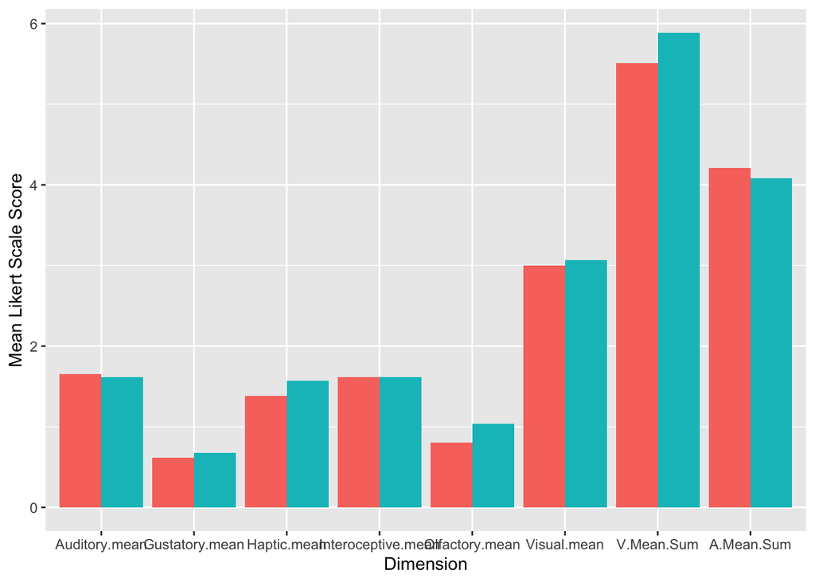

```r
####Make plot of means by Dimension
plot1<-ggplot(statprep2.long,aes(x=variable,y=value,fill=factor(Condition)))+
  geom_bar(stat="identity",position="dodge")+
  scale_fill_discrete(name="Condition",
                      breaks=c(1, 2),
                      labels=c("Case", "Control"))+
  xlab("Dimension")+ylab("Mean Likert Scale Score")
plot1
```

Looks like most of the dimensions are fairly similar. Let’s run some statistical tests to compare Olfactory.mean (i.e., average smell salience of words used) and V.Mean.Sum (i.e., average positivity/negativity of words used) between groups.

# 8 8. Run Crawford Statistics

The Crawford Test is a t-test for single subject analysis. Here, you compare an average of your single subject (i.e., case) to an average of a group of controls. You will need to do a few simple calculations before running the test: (1) case Mean, (2) control Mean, (3) control Standard Deviation, (4) number of controls

```r
#Get Mean of Subject and Control for Olfactory Mean
mean(fullbag$Olfactory.mean, na.rm=TRUE) #Case Mean
```

```
## [1] 1.034051
```

```r
mean(fullbagc$Olfactory.mean, na.rm=TRUE) # Control Mean
```

```
## [1] 0.8045087
```

```r
sd(fullbagc$Olfactory.mean, na.rm=TRUE)  #Control SD
```

```
## [1] 1.097594
```

```r
#Run the Test
crawford.test(patient = 1.034051, mean = .8045087, sd = 1.097, n = 20)
```

```
## The Bayesian test for single case assessment (Crawford, Garthwaite, 2007) suggests that the patient's score (Raw = 1.03, Z = 0.21, percentile = 58.29) is not significantly different from the controls (M = 0.80, SD = 1.10, p p = 0.403). The patient's score is higher than 59.69% (95% CI [0.28, 0.50…
```

```r
#Get Mean of Subject and Control for Valence Mean
mean(fullbag$V.Mean.Sum, na.rm=TRUE) #Case Mean
```

```
## [1] 5.888491
```

```r
mean(fullbagc$V.Mean.Sum, na.rm=TRUE) # Control Mean
```

```
## [1] 5.507227
```

```r
sd(fullbagc$V.Mean.Sum, na.rm=TRUE)  #Control SD
```

```
## [1] 1.462159
```

```r
#Run the Test
crawford.test(patient = 5.888491, mean = 5.507227, sd = 1.462159, n = 20)
```

```
## The Bayesian test for single case assessment (Crawford, Garthwaite, 2007) suggests that the patient's score (Raw = 5.89, Z = 0.26, percentile = 60.29) is not significantly different from the controls (M = 5.51, SD = 1.46, p p = 0.389). The patient's score is higher than 61.12% (95% CI [0.26, 0.50…
```